# Step 2.03: Symptom Outcome Exploration

Mia Charifson

2024-02-12

## Introduction

The goal of this document is to:

1. define the timing of the first symptom related to UF and Endo symptomology for each patient (never, before entry, at baseline, during follow-up)
2. explore the UF and Endo symptomolgy in our cohort population (which symptom, how many times)

```r
pat_cohort <- read.csv('Data/Derived/pat_cohort_w_censoring.csv')
ever_proc_info <- read.csv('Data/Derived/Chapter 1/cohort_w_uf.csv')
symptoms1 <- read.csv('Data/Epic/table3_dx_symptoms1.csv')
symptoms2 <- read.csv('Data/Epic/table3_dx_symptoms2.csv')
uf_hints <- read.csv('Data/Derived/uf_all_hints.csv')
endo_hints <- read.csv('Data/Derived/endo_all_hints.csv')
```

```r
pat_cohort_new <- pat_cohort %>%
  left_join(uf_hints %>%
              filter(confident_incident) %>%
              select(pat_id, first_dx_date, first_confirm_date,
                     first_confirm_type, first_location_date) %>%
              rename_all(~paste0("uf_", .)),
            by=c('pat_id' = 'uf_pat_id')) %>%
  left_join(endo_hints %>%
              filter(confident_incident) %>%
              select(pat_id, first_dx_date, first_confirm_date,
                     first_confirm_type, first_location_date) %>%
              rename_all(~paste0("endo_", .)),
            by=c('pat_id' = 'endo_pat_id')) %>%
  mutate(uf_dx = case_when(!is.na(uf_first_dx_date)~TRUE, TRUE~FALSE),
         endo_dx = case_when(!is.na(endo_first_dx_date)~TRUE, TRUE~FALSE),
         uf_first_dx_date = as.Date(uf_first_dx_date),
         endo_first_dx_date = as.Date(endo_first_dx_date),
         final_outcome_status = case_when((uf_dx & endo_dx) & uf_first_dx_date < endo_first_dx_date~'UF',
                                   (uf_dx & endo_dx) & uf_first_dx_date > endo_first_dx_date~'Endo',
                                   (uf_dx & endo_dx) & uf_first_dx_date == endo_first_dx_date~'Both',
                                   uf_dx & !endo_dx~'UF',
                                   !uf_dx & endo_dx~'Endo',
                                   !uf_dx & !endo_dx~'Control'),
         first_outcome_dx_date = case_when(final_outcome_status %in% c('UF', 'Both')~uf_first_dx_date,
                                           final_outcome_status == 'Endo'~endo_first_dx_date),
         outcome_before_censor = case_when(is.na(final_censor_date)~TRUE,
                                           first_outcome_dx_date <= final_censor_date~TRUE,
                                           TRUE~FALSE),
         final_censor_type_outcome = case_when(final_outcome_status != 'Control' & outcome_before_censor~'Case',
                                              final_outcome_status %in% c('UF', 'Both') &
                                                final_censor_type==uf_first_confirm_type~'Case',
                                              final_outcome_status == 'Endo' &
                                                final_censor_type==endo_first_confirm_type~'Case',
                                              TRUE~final_censor_type),
         final_censor_date_outcome = case_when(final_censor_type_outcome=='Case'~first_outcome_dx_date,
                                              TRUE~as.Date(final_censor_date)))
```

```r
symptoms <- bind_rows(symptoms1, symptoms2) %>%
  inner_join(pat_cohort %>% select(pat_id, index_enc_date), by='pat_id')
```

## First, some cleaning

There are 130348 entries where the date of the diagnosis code is missing. All of these are `Medical History` type diagnoses. These are generally uninformative without a diagnosis date.

TO DO: try to recover diagnosis dates for as many of these rows as possible, by joining on encounter ID.

```r
table(symptoms$dx_type[which(symptoms$dx_date=='NULL')])

symptoms %>%
  group_by(pat_id) %>%
  filter(n() == sum(dx_type == 'Medical History')) %>%
  arrange(pat_id)
```

## Symptom descriptives

There are 46610 patients in our cohort who have at least one UF or Endo related symptom in their EHR. Since back pain and diarhhea are relatively non-specific symptoms, we only count them as the first symptom if they are later followed by another UF/Endo related symptom.

```r
first_symptom <- symptoms %>%
  group_by(pat_id) %>%
  summarise(index_enc_date = min(index_enc_date),
            first_dx_date = min(dx_date, na.rm=TRUE),
            first_dx_names = paste0(unique(dx_name),collapse = ', '),
            icd10s = paste0(unique(icd10),collapse = ', '),
            n_specific_symptoms = sum(!grepl('M54.5|R19.7', icd10)),
            symptom_count = length(unique(dx_name)),
            .groups='drop') %>%
  mutate(first_dx_date = as.Date(first_dx_date),
         index_enc_date = as.Date(index_enc_date),
         time_group = case_when(first_dx_date<index_enc_date~'before baseline',
                                first_dx_date>=index_enc_date&first_dx_date<=(ymd(index_enc_date)+years(1))~'at baseline',
                                first_dx_date>(ymd(index_enc_date)+years(1))~'during follow-up',
                                TRUE~'has symptom, no date'),
         # flag symptom case if they have back pain/diarrhea and no other specific UF/Endo symptoms
         flag = case_when(grepl('M54.5|R19.7', icd10s) & n_specific_symptoms == 0~TRUE,
                          TRUE~FALSE))

flag_ids <- unique(first_symptom$pat_id[which(first_symptom$flag)])
```

The following questions get explored:

1. When do patients have their first UF or Endo related symptom?
2. For patients who have symptoms, how many symptoms do they report since their first one?
3. Which symptoms are commonly reported in this cohort?
4. Which symptom is commonly reported for the first symptom at baseline & during follow-up?
5. What symptoms are associated with each other?

### 1

```r
pat_cohort %>%
  select(pat_id) %>%
  left_join(first_symptom %>% filter(!flag), by='pat_id') %>%
  mutate(time_group = ifelse(is.na(time_group), 'never', time_group)) %>%
  tableby(~time_group, data=.) %>%
  summary()
```

|  | Overall (N=82084) |
| --- | --- |
| **time_group** |  |
| at baseline | 12122 (14.8%) |
| before baseline | 8384 (10.2%) |
| during follow-up | 16405 (20.0%) |
| has symptom, no date | 578 (0.7%) |
| never | 44595 (54.3%) |

### 2

A distinct symptom is counted as a unique diagnosis date-ICD10 code combinations.

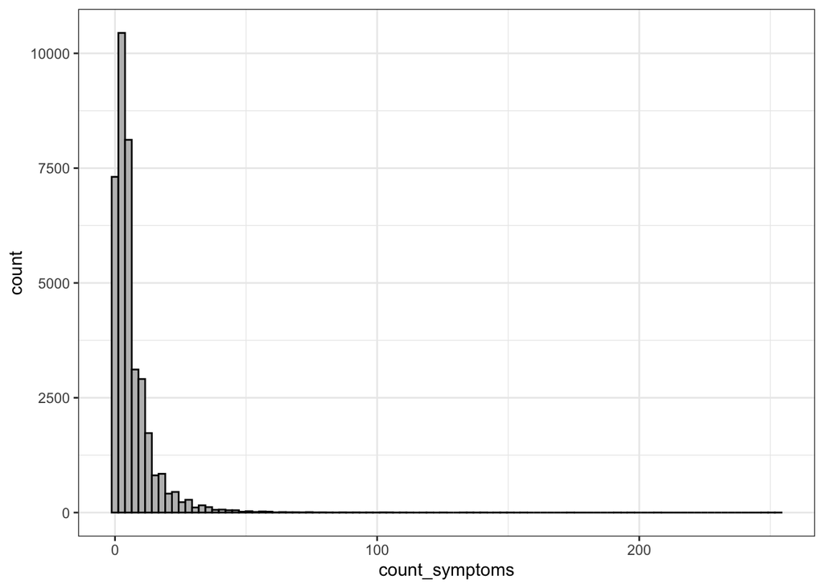

```r
symptoms %>%
  filter(!pat_id %in% flag_ids) %>%
  group_by(pat_id) %>%
  summarise(count_symptoms = n_distinct(dx_date, icd10), .groups='drop') %>%
  ggplot(aes(x=count_symptoms), data=.) +
  geom_histogram(fill= 'gray', color='black', bins = 100) +
  theme_bw()
```

```r
symptoms %>%
  filter(!pat_id %in% flag_ids) %>%
  group_by(pat_id) %>%
  summarise(count_symptoms = n_distinct(dx_date, icd10), .groups='drop') %>%
  tableby(~count_symptoms, data=., numeric.stats = c('mean', 'median', 'q1q3', 'range')) %>%
  summary()
```

|  | Overall (N=37489) |
| --- | --- |
| **count_symptoms** |  |
| Mean | 6.546 |
| Median | 4.000 |
| Q1, Q3 | 2.000, 8.000 |
| Range | 1.000 - 254.000 |

### 3

```r
symptom_wide_boolean <- symptoms %>%
  filter(!pat_id %in% flag_ids) %>%
  group_by(pat_id, dx_date) %>%
  summarise(Pelvic_pain = (sum(grepl('R10.2', icd10))>=1),
         Dysmenorrhea = (sum(grepl('N94.[4-6]', icd10))>=1),
         Dyspareunia = (sum(grepl('F52.6|N94.1', icd10))>=1),
         Infertility = (sum(grepl('N97.9', icd10))>=1),
         Intermenstrual_pain = (sum(grepl('N94.0', icd10))>=1),
         Ovarian_cysts = (sum(grepl('N83.0|N83.2', icd10))>=1),
         Anemia = (sum(grepl('D50.0', icd10))>=1),
         Back_pain = (sum(grepl('M54.5', icd10))>=1),
         Postcoital_bleed = (sum(grepl('N93.0', icd10))>=1),
         AUB = (sum(grepl('N93.8|N93.9', icd10))>=1),
         Diarrhea = (sum(grepl('R19.7', icd10))>=1),
         Menorrhagia = (sum(grepl('N92.0|N92.1', icd10))>=1),
         Bladder_rectum_symptoms = (sum(grepl('N32.9|K59.00', icd10))>=1),
         Urinary_urgency = (sum(grepl('N39.3', icd10))>=1),
         PID = (sum(grepl('N73.9', icd10))>=1),
         .groups='drop')
```

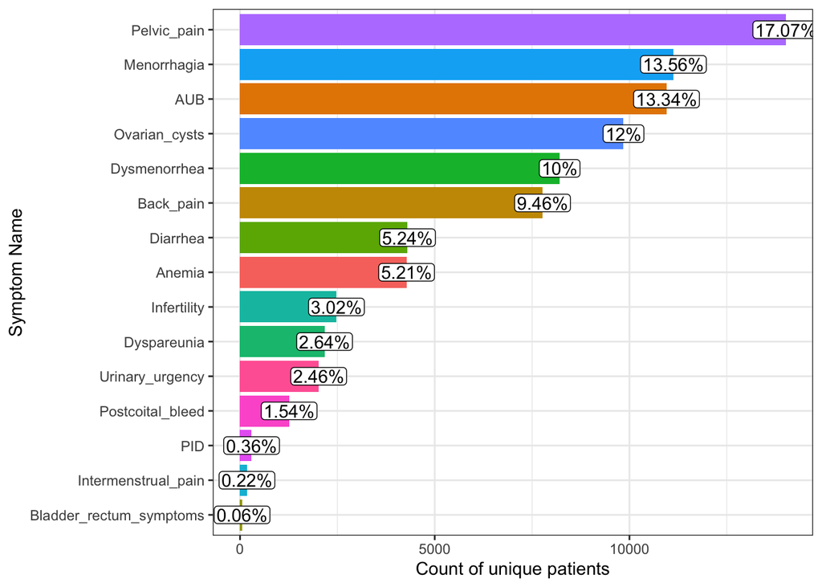

```r
patient_counts <- symptom_wide_boolean %>%
  summarise(Pelvic_pain = n_distinct(pat_id[Pelvic_pain]),
         Dysmenorrhea = n_distinct(pat_id[Dysmenorrhea]),
         Dyspareunia = n_distinct(pat_id[Dyspareunia]),
         Infertility = n_distinct(pat_id[Infertility]),
         Intermenstrual_pain = n_distinct(pat_id[Intermenstrual_pain]),
         Ovarian_cysts = n_distinct(pat_id[Ovarian_cysts]),
         Anemia = n_distinct(pat_id[Anemia]),
         Back_pain = n_distinct(pat_id[Back_pain]),
         Postcoital_bleed = n_distinct(pat_id[Postcoital_bleed]),
         AUB = n_distinct(pat_id[AUB]),
         Diarrhea = n_distinct(pat_id[Diarrhea]),
         Menorrhagia = n_distinct(pat_id[Menorrhagia]),
         Bladder_rectum_symptoms = n_distinct(pat_id[Bladder_rectum_symptoms]),
         Urinary_urgency = n_distinct(pat_id[Urinary_urgency]),
         PID = n_distinct(pat_id[PID]),) %>%
  pivot_longer(cols=everything(), names_to='Symptom', values_to='Count') %>%
  mutate(Percent = paste0(round(Count/nrow(pat_cohort)*100, 2), '%'))

patient_counts %>%
  ggplot(aes(x=Count, y=fct_reorder(Symptom, Count), fill=Symptom), data=.) +
  geom_col() +
  geom_label(aes(label=Percent), fill='white', label.padding = unit(0.1, "lines")) +
  theme_bw() +
  ylab('Symptom Name') +
  xlab('Count of unique patients') +
  theme(legend.position = 'none')
```

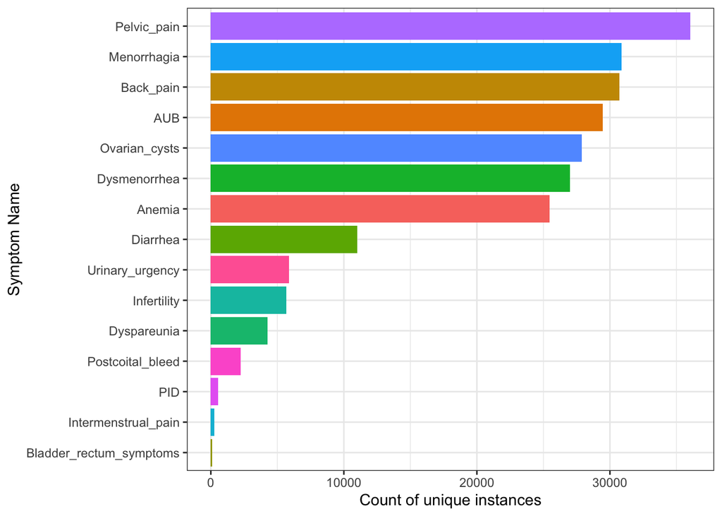

```r
symptom_wide_boolean %>%
  summarise(Pelvic_pain = sum(Pelvic_pain),
         Dysmenorrhea = sum(Dysmenorrhea),
         Dyspareunia = sum(Dyspareunia),
         Infertility = sum(Infertility),
         Intermenstrual_pain = sum(Intermenstrual_pain),
         Ovarian_cysts = sum(Ovarian_cysts),
         Anemia = sum(Anemia),
         Back_pain = sum(Back_pain),
         Postcoital_bleed = sum(Postcoital_bleed),
         AUB = sum(AUB),
         Diarrhea = sum(Diarrhea),
         Menorrhagia = sum(Menorrhagia),
         Bladder_rectum_symptoms = sum(Bladder_rectum_symptoms),
         Urinary_urgency = sum(Urinary_urgency),
         PID = sum(PID)) %>%
  pivot_longer(cols=everything(), names_to='Symptom', values_to='Count') %>%
  ggplot(aes(x=Count, y=fct_reorder(Symptom, Count), fill=Symptom), data=.) +
  geom_col() +
  theme_bw() +
  ylab('Symptom Name') +
  xlab('Count of unique instances') +
  theme(legend.position = 'none')
```

### 4

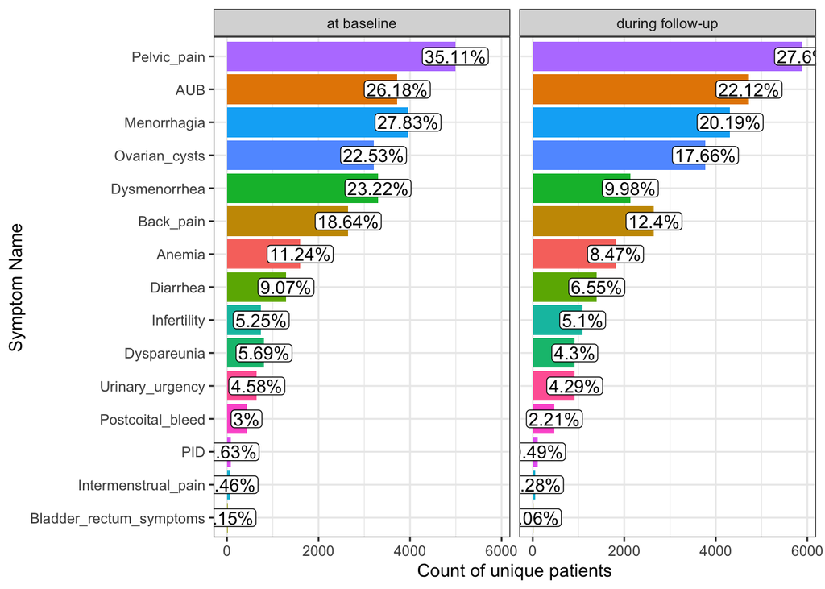

```r
n_timegroup <- table(first_symptom$time_group)
patient_counts <- first_symptom %>%
  filter(!flag) %>%
  group_by(time_group) %>%
  summarise(Pelvic_pain = (sum(grepl('R10.2', icd10s))),
         Dysmenorrhea = (sum(grepl('N94.[4-6]', icd10s))),
         Dyspareunia = (sum(grepl('F52.6|N94.1', icd10s))),
         Infertility = (sum(grepl('N97.9', icd10s))),
         Intermenstrual_pain = (sum(grepl('N94.0', icd10s))),
         Ovarian_cysts = (sum(grepl('N83.0|N83.2', icd10s))),
         Anemia = (sum(grepl('D50.0', icd10s))),
         Back_pain = (sum(grepl('M54.5', icd10s))),
         Postcoital_bleed = (sum(grepl('N93.0', icd10s))),
         AUB = (sum(grepl('N93.8|N93.9', icd10s))),
         Diarrhea = (sum(grepl('R19.7', icd10s))),
         Menorrhagia = (sum(grepl('N92.0|N92.1', icd10s))),
         Bladder_rectum_symptoms = (sum(grepl('N32.9|K59.00', icd10s))),
         Urinary_urgency = (sum(grepl('N39.3', icd10s))),
         PID = (sum(grepl('N73.9', icd10s)))) %>%
  pivot_longer(cols=c(Pelvic_pain:PID), names_to='Symptom', values_to='Count') %>%
  mutate(Percent = case_when(time_group == 'at baseline' ~ Count/n_timegroup[1],
                             time_group == 'during follow-up' ~ Count/n_timegroup[3],
                             time_group == 'before baseline' ~ Count/n_timegroup[2]),
         Percent = paste0(round(Percent*100, 2), '%'))

patient_counts %>%
  filter(time_group %in% c('at baseline', 'during follow-up')) %>%
  ggplot(aes(x=Count, y=fct_reorder(Symptom, Count), fill=Symptom), data=.) +
  geom_col() +
  geom_label(aes(label=Percent), fill='white', label.padding = unit(0.1, "lines")) +
  theme_bw() +
  ylab('Symptom Name') +
  xlab('Count of unique patients') +
  theme(legend.position = 'none') +
  facet_wrap(~time_group)
```

### 5

```r
symptom_wide <- symptoms %>%
  filter(!pat_id %in% flag_ids) %>%
  group_by(pat_id, dx_date) %>%
  summarise(Pelvic_pain = (sum(grepl('R10.2', icd10))>=1),
         Dysmenorrhea = (sum(grepl('N94.[4-6]', icd10))>=1),
         Dyspareunia = (sum(grepl('F52.6|N94.1', icd10))>=1),
         Infertility = (sum(grepl('N97.9', icd10))>=1),
         Intermenstrual_pain = (sum(grepl('N94.0', icd10))>=1),
         Ovarian_cysts = (sum(grepl('N83.0|N83.2', icd10))>=1),
         Anemia = (sum(grepl('D50.0', icd10))>=1),
         Back_pain = (sum(grepl('M54.5', icd10))>=1),
         Post_coital_bleed = (sum(grepl('N93.0', icd10))>=1),
         AUB = (sum(grepl('N93.8|N93.9', icd10))>=1),
         Diarrhea = (sum(grepl('R19.7', icd10))>=1),
         Menorrhagia = (sum(grepl('N92.0|N92.1', icd10))>=1),
         Bladder_rectum_symptoms = (sum(grepl('N32.9|K59.00', icd10))>=1),
         Urinary_urgency = (sum(grepl('N39.3', icd10))>=1),
         PID = (sum(grepl('N73.9', icd10))>=1),
         .groups='drop')
```

```r
symptom_wide_count <- symptoms %>%
  filter(!pat_id %in% flag_ids) %>%
  group_by(pat_id) %>%
  summarise(Pelvic_pain = (sum(grepl('R10.2', icd10))),
         Dysmenorrhea = (sum(grepl('N94.[4-6]', icd10))),
         Dyspareunia = (sum(grepl('F52.6|N94.1', icd10))),
         Infertility = (sum(grepl('N97.9', icd10))),
         Intermenstrual_pain = (sum(grepl('N94.0', icd10))),
         Ovarian_cysts = (sum(grepl('N83.0|N83.2', icd10))),
         Anemia = (sum(grepl('D50.0', icd10))),
         Back_pain = (sum(grepl('M54.5', icd10))),
         Post_coital_bleed = (sum(grepl('N93.0', icd10))),
         AUB = (sum(grepl('N93.8|N93.9', icd10))),
         Diarrhea = (sum(grepl('R19.7', icd10))),
         Menorrhagia = (sum(grepl('N92.0|N92.1', icd10))),
         Bladder_rectum_symptoms = (sum(grepl('N32.9|K59.00', icd10))),
         Urinary_urgency = (sum(grepl('N39.3', icd10))),
         PID = (sum(grepl('N73.9', icd10))),
         .groups='drop')
```

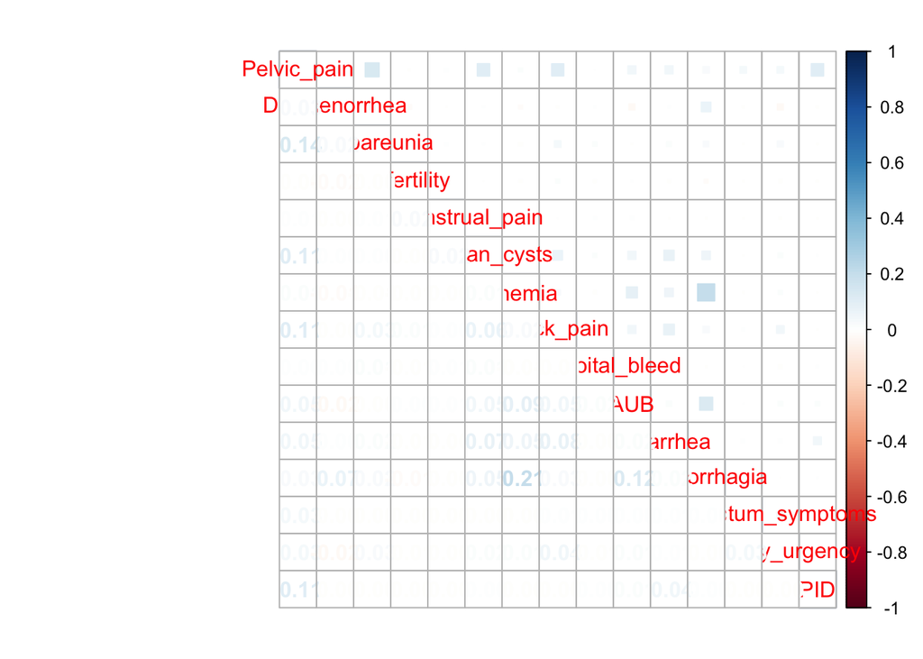

```r
corrplot.mixed(cor(symptom_wide_count[, -c(1)]), upper = 'square')
```

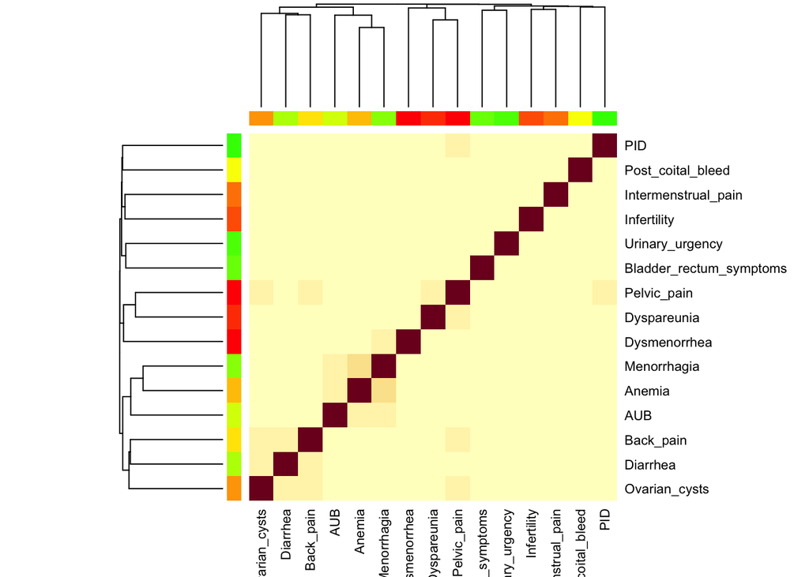

```r
require(graphics); require(grDevices)
x <- cor(symptom_wide_count[, -c(1)])
rc <- rainbow(nrow(x), start = 0, end = .3)
cc <- rainbow(ncol(x), start = 0, end = .3)
heatmap(x, RowSideColors = rc, ColSideColors = cc)
```

## Time to diagnoisis

```r
pat_cohort_symptoms <- pat_cohort_new %>%
  inner_join(first_symptom %>%
              filter(time_group %in% c('at baseline', 'during follow-up') & !flag) %>%
              rename(first_symptom_date = first_dx_date,
                     first_symptom_dx_name = first_dx_names,
                     first_symptom_icd10s = icd10s) %>%
              select(-index_enc_date, -n_specific_symptoms, -time_group, -flag),
            by='pat_id') %>%
  # make final censor date end of FU if NA
  mutate(final_censor_date_outcome = case_when(is.na(final_censor_date_outcome)~as.Date('2023-08-01'),
                                               TRUE~final_censor_date_outcome))
```

There are 28527 patients with a first symptom during follow-up. However, further exclusions must be made if the first symptom is at or after censoring/after outcome diagnosis (n=3640).

```r
pat_cohort_symptoms <- pat_cohort_symptoms %>%
  filter(first_symptom_date < final_censor_date_outcome)
```

The following descriptives are reported:

1. TTD overall in cohort
2. TTD by outcome status
3. TTD by first symptom type
4. First symptom type by outcome status

### 1

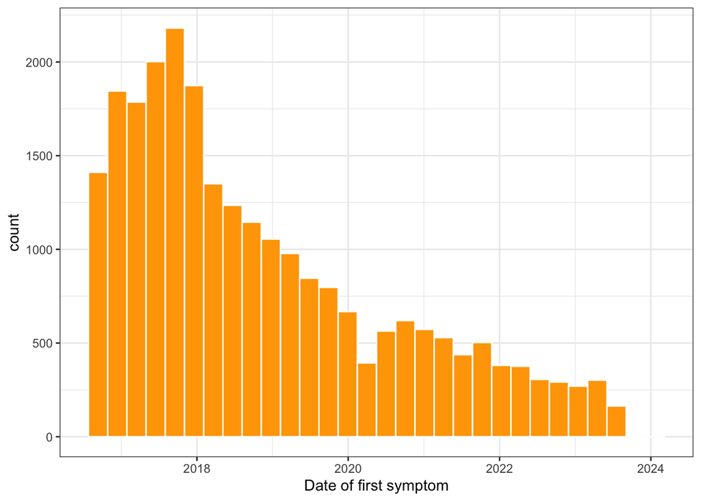

```r
pat_cohort_symptoms %>%
  ggplot(data=.) +
  geom_histogram(aes(x=first_symptom_date), fill='orange', color='white', bins=30) +
  xlab('Date of first symptom') +
  theme_bw()
```

### 2

```r
pat_cohort_symptoms$ttd <- as.numeric(difftime(pat_cohort_symptoms$final_censor_date_outcome,
                                               pat_cohort_symptoms$first_symptom_date,
                                               unit='days'))/30
## show table for ttd by outcome status
summary(tableby(final_outcome_status~ttd, data=pat_cohort_symptoms),
        labelTranslations= list('ttd'='Time to diagnosis (months)'))
```

|  | Both (N=60) | Control (N=21690) | Endo (N=569) | UF (N=2568) | Total (N=24887) | p value |
| --- | --- | --- | --- | --- | --- | --- |
| **Time to diagnosis (months)** |  |  |  |  |  | < 0.001 |
| Mean (SD) | 18.338 (20.385) | 45.303 (25.317) | 20.748 (19.919) | 20.436 (19.630) | 42.110 (26.030) |  |
| Range | 0.100 - 71.133 | 0.033 - 90.167 | 0.033 - 81.233 | 0.033 - 81.233 | 0.033 - 90.167 |  |

### 3

```r
pat_cohort_symptoms %>%
  mutate(symptom_type = case_when(grepl('R10.2|F52.6|N94.1|N94.0|M54.5', first_symptom_icd10s)~'Pain',
                                  grepl('N94.[4-6]|N93.0|N93.8|N93.9|N92.0|N92.1|D50.0',
                                             first_symptom_icd10s)~'Menstrual/Bleeding',
                                  grepl('N83.0|N83.2|N73.9', first_symptom_icd10s)~'PID/Ovarian cysts',
                                  grepl('N97.9', first_symptom_icd10s)~'Infertility',
                                  grepl('N32.9|K59.00|N39.3|R19.7', first_symptom_icd10s)~
                                    'Other Genito-urinary')) %>%
  tableby(symptom_type~ttd, data=.) %>%
  summary(., labelTranslations= list('ttd'='Time to diagnosis (months)'))
```

|  | Infertility (N=631) | Menstrual/Bleeding (N=9740) | Other Genito-urinary (N=365) | Pain (N=12933) | PID/Ovarian cysts (N=1218) | Total (N=24887) | p value |
| --- | --- | --- | --- | --- | --- | --- | --- |
| **Time to diagnosis (months)** |  |  |  |  |  |  | < 0.001 |
| Mean (SD) | 36.152 (24.583) | 40.105 (25.952) | 35.851 (24.155) | 44.610 (25.945) | 36.564 (25.810) | 42.110 (26.030) |  |
| Range | 0.033 - 84.633 | 0.033 - 86.467 | 0.033 - 84.633 | 0.033 - 89.967 | 0.067 - 90.167 | 0.033 - 90.167 |  |

Pain includes pelvic pain, dyspareunia, inter-menstrual pain, and back pain. Menstrual/bleeding includes dysmenorrhea, anemia, post-coital bleed, abnormal uterine bleeding, and menorrhagia. Infertility just includes infertility. Other genito-urinary symptoms include diarrhea, bladder and rectum symptoms, and urinary urgency. PID and ovarian cysts have their own category as they are related diagnoses which may be misdiagnoses or intermediary diagnoses that then warrant further screening.

### 4

```r
pat_cohort_symptoms %>%
  mutate(symptom_type = case_when(grepl('R10.2|F52.6|N94.1|N94.0|M54.5', first_symptom_icd10s)~'Pain',
                                  grepl('N94.[4-6]|N93.0|N93.8|N93.9|N92.0|N92.1|D50.0',
                                             first_symptom_icd10s)~'Menstrual/Bleeding',
                                  grepl('N83.0|N83.2|N73.9', first_symptom_icd10s)~'PID/Ovarian cysts',
                                  grepl('N97.9', first_symptom_icd10s)~'Infertility',
                                  grepl('N32.9|K59.00|N39.3|R19.7', first_symptom_icd10s)~
                                    'Other Genito-urinary')) %>%
  tableby(final_outcome_status~symptom_type, data=.) %>%
  summary(., labelTranslations= list('final_outcome_status'='Patient outcome group'))
```

|  | Both (N=60) | Control (N=21690) | Endo (N=569) | UF (N=2568) | Total (N=24887) | p value |
| --- | --- | --- | --- | --- | --- | --- |
| **symptom_type** |  |  |  |  |  | < 0.001 |
| Infertility | 0 (0.0%) | 601 (2.8%) | 2 (0.4%) | 28 (1.1%) | 631 (2.5%) |  |
| Menstrual/Bleeding | 19 (31.7%) | 8707 (40.1%) | 96 (16.9%) | 918 (35.7%) | 9740 (39.1%) |  |
| Other Genito-urinary | 1 (1.7%) | 354 (1.6%) | 1 (0.2%) | 9 (0.4%) | 365 (1.5%) |  |
| Pain | 40 (66.7%) | 10910 (50.3%) | 451 (79.3%) | 1532 (59.7%) | 12933 (52.0%) |  |
| PID/Ovarian cysts | 0 (0.0%) | 1118 (5.2%) | 19 (3.3%) | 81 (3.2%) | 1218 (4.9%) |  |

## Identifying potential false negatives

False negatives are defined as patients with at least two distinct symptoms related to UF and/or Endo with no UF and Endo diagnostic codes. Below I will identify and flag these patients and also separate them into those with and without diagnostic procedures.

I leave off back pain and diarrhea off this as they are non-specific symptoms. I allow symptoms to occur anytime prior to the final censoring date (including case diagnosis) since for identifying false negatives, we do not care if their symptoms occur prior to baseline.

```r
false_negatives <- symptoms %>%
  inner_join(pat_cohort_new %>%
               select(pat_id, final_censor_date_outcome),
            by='pat_id') %>%
  filter(dx_date <= final_censor_date_outcome) %>%
  group_by(pat_id) %>%
  summarise(n_specific_symptoms = sum(!grepl('M54.5|R19.7', icd10)),
            .groups='drop') %>%
  filter(n_specific_symptoms > 1) %>%
  left_join(ever_proc_info %>% select(pat_id, ever_imaging, ever_surgery), by='pat_id') %>%
  filter(!pat_id %in% pat_cohort_new$pat_id[which(pat_cohort_new$final_censor_type_outcome == 'Case')])
```

There are 6732 patients who report at least two symptoms related to UF/Endo but never receive a UF or Endo diagnosis. Of these, there are 1883 patients who additionally never received any imaging or surgery procedures commonly used to diagnose UF/Endo during follow-up . This amounts to about 2.29% of patients being qualified as potential false negatives.

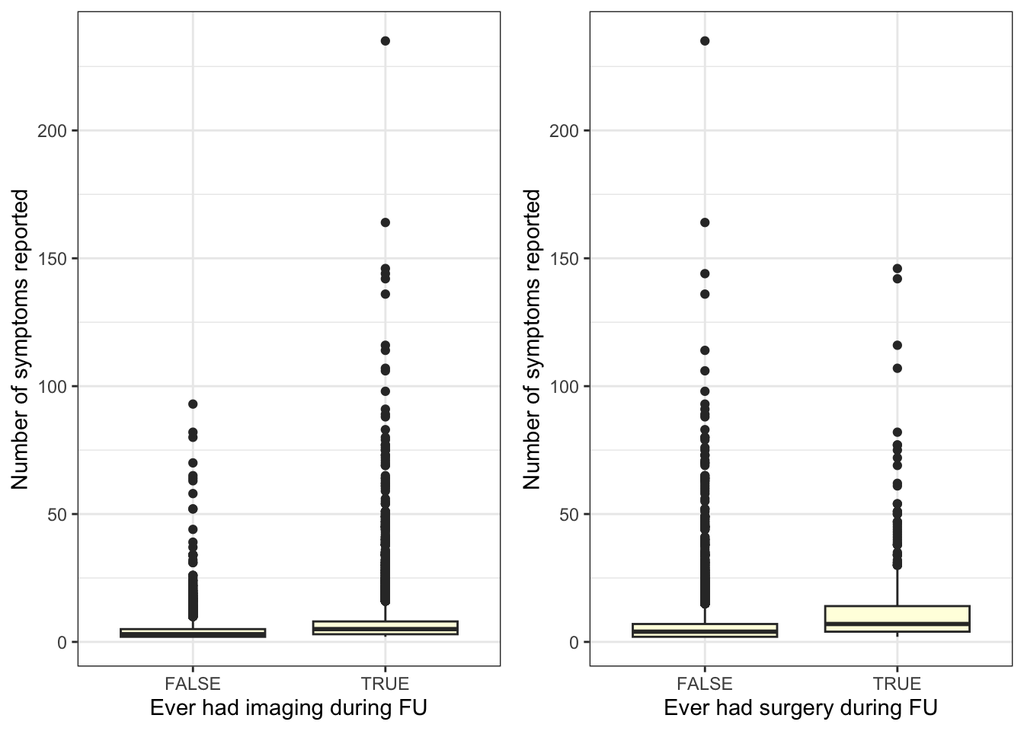

```r
p1 <- ggplot(data=false_negatives, aes(y=n_specific_symptoms, x=ever_imaging)) +
  geom_boxplot(fill='lightyellow') +
  xlab('Ever had imaging during FU') +
  ylab('Number of symptoms reported') +
  theme_bw()

p2 <- ggplot(data=false_negatives, aes(x=ever_surgery, y=n_specific_symptoms)) +
  geom_boxplot(fill='lightyellow') +
  xlab('Ever had surgery during FU') +
  ylab('Number of symptoms reported') +
  theme_bw()

ggarrange(p1, p2)
```

## Write output files

```r
# write out false negatives and chapter 2 cohort
write.csv(pat_cohort_symptoms, 'Data/Derived/Chapter 2/pat_cohort_w_ttd.csv', row.names = FALSE)
write.csv(false_negatives, 'Data/Derived/putative_false_negatives.csv', row.names = FALSE)
```